# Digital Capacities Index - Quantitative Findings

##### Attitudes towards Technology

The survey asked respondents to what extent they agree or disagree with a number of statements with regards to attitudes towards broader issues concerning technology.

Similar to our findings on the more general statements about online risks and harms, the attitudes of respondents towards technology is especially positive with over 60% reporting being optimistic about the future of technology. Nearly three quarters (74%) agree or strongly agree that technology is part of everyday life. Nearly half (49%) believe that technology can not only make participants more effective members of their community or nation, but can also foster social inclusion.

The positive attitude is nevertheless counterbalanced with concerns about the use of online information by governments or companies, the impact on the environment or the growing divide between technology experts and the rest of society.

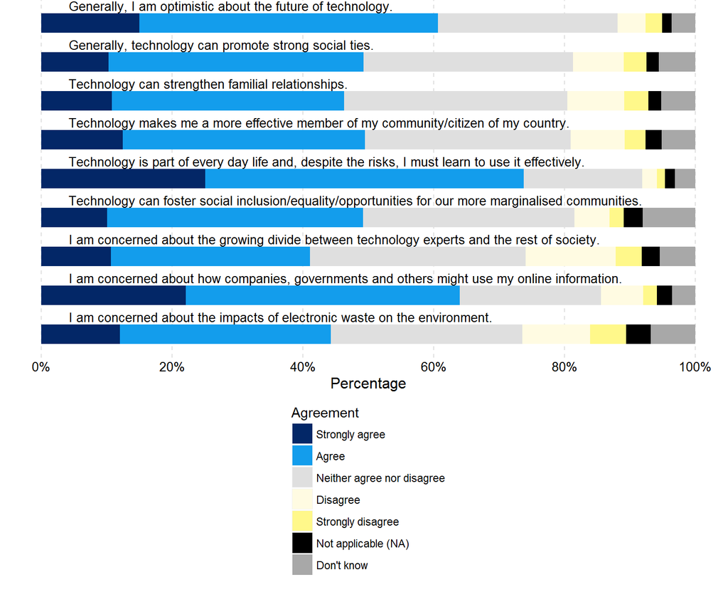

**Figure 31: Attitudes towards Technology**

#### Results by Age

##### Family

Across all age groups, a large proportion of respondents reported that their online life was extremely important in maintaining relationships with family members.

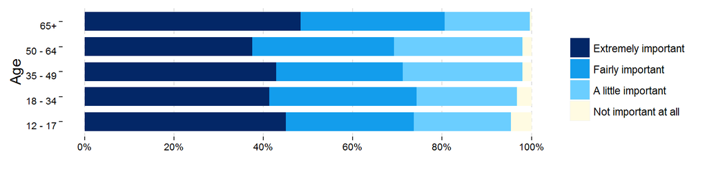

**Figure 32: Family**

##### Shared pictures of yourself with your family or friends (e.g. through a social networking site, photo sharing site)

The ways in which people maintain connections with others online, however, differ depending on the people’s age. The likelihood of sharing pictures of oneself with family or friends decreases with age, with half of 12-17 year olds doing so weekly or more often compared to less than a fifth of those aged 65 or over.

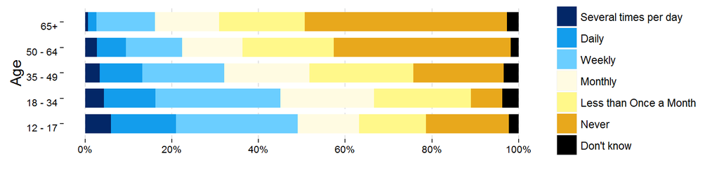

**Figure 33: Shared pictures of yourself with your family or friends (e.g. through a social networking site, photo sharing site)**

##### I am concerned about how companies, governments and others might use my online information.

Overall, respondents largely agreed to being concerned about how companies, governments or others might use their online information, and results are consistent across all age groups.

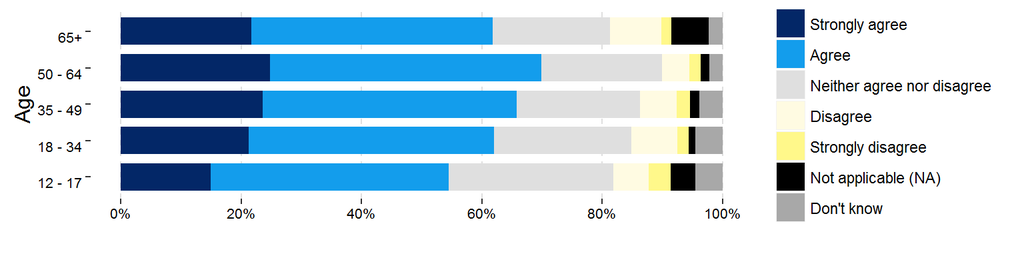

**Figure 34: I am concerned about how companies, governments and others might use my online information.**

## Overall results

### Aggregates by Critical Issue

To gain an overall picture of our results, we generated a series of stacked graphs in *Figure 35: Aggregated Results by Critical Issue*. These aggregate responses to each critical issue (*Competencies*, *Interests*, *Resilience* and *Competencies*), and the combined total.

These results are indicative only, and have several evident limitations we discuss further below. The procedure to generate scores for each of the issues is as follows:

1. Interpret each question as having either a *positive* or *negative* influence of the score of the critical issue. For example, “Frequency of harmful events” has a *negative influence* on the issue of Resilience (and indeed, on overall “Digital Capacities”).
2. Determine the *direction* of the scale coding. For example, in all of our “Agreement” questions, “Strongly Agree” was coded **1**.
3. For each question, calculate a question score based on both its interpretation and direction, by adding responses to individual items.
4. For each respondent, add each of their question scores to produce a respondent critical issue score. This value is converted to a percentile, where ‘100%’ would indicate maximum responses to each item for each question in that critical issue.
5. A combined score is taken by averaging the four critical issue scores.

Figure 35 then displays the relative frequencies of these scores, similar to the preceding individual question graphs. Because values are continuous (anywhere on a scale between 0 and 100 per cent), the graphs show a spectrum from blue (indicating a low score) to bright yellow (indicating a high score).

The *Resilience* score is calculated in the same way as the other issue scores, with the exception that only the first two items under *Question 428*, “Willingness to engage with others”, are included in the scoring procedure. We have intepreted these items (“When I am going through a difficult time, I go online less often”; “When I am going through a difficult time, going online makes me feel better”) as having some influence (the first negative, the second positive) on *Resilience*.

#### Limitations

The above procedure has several limitations.

First, it is questionable whether complex concepts such as digital resilience and social connectedness, in particular, are reducible to a quantitative value, regardless of the procedure used to derive it. Further, for reasons of space, our characterisation of Digital Capacities includes a total of nine critical issues, only four of which are included in the survey. We recommend comparing these scores with our qualitative findings, which illustrate the more nuanced and sometimes contradictory character of these qualities in Australian families.

Third, the procedure assumes all questions and individual items have equal influence on the critical issue they have been aligned to.

**[REVIEW NOTE: The latter two of these issues can be addressed partially by a more sophisticated scaling and weighting approach. We are considering holding a workshop for this purpose in preparation of the complete draft meeting in May 2016.]**

### Observations

Bearing in mind the method of deriving these aggregate scores, we make only minimal observations at this stage. *Figure 35* shows that results for *Compentencies* and *Connectedness* are evenly distributed, with respondents’ scores spread across the 100-point scale. These are also similar to the spread of *Combined* scores. *Resilience* scores tend high, with most respondents reporting little exposure to harms, and familiarity with methods for responding to those harms.

On the other hand, *Interest* scores tend low. This may be explained by our limiting interests to areas of social difference, fitness, health and family, which will not effectively poll the range or extent of participants’ interests.

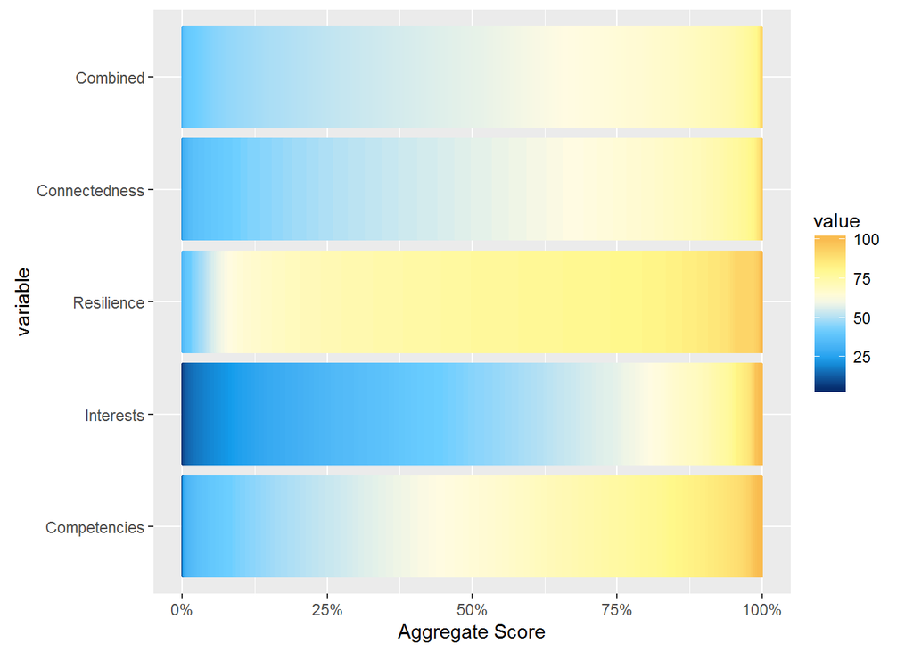

*Figure 35: Aggregated Results by Critical Issue*

## References

Helsper, Ellen. 2012. “A Corresponding Fields Model for the Links Between Social and Digital Exclusion.” *Communication Theory* 22 (4). Wiley Online Library: 403–26.

Humphry, Justine. 2014. “The Importance of Circumstance: Digital Access and Affordability for People Experiencing Homelessness.” *Australian Journal of Telecommunications and the Digital Economy* 2 (3). Telecommunications Association: 55.

James, Paul. 2014. *Urban Sustainability in Theory and Practice: Circles of Sustainability*. Routledge.

Livingstone, Sonia, Leslie Haddon, Anke Görzig, and Kjartan Ólafsson. 2010. “Risks and Safety on the Internet: The Perspective of European Children: Key Findings from the EU Kids Online Survey of 9-16 Year Olds and Their Parents in 25 Countries.” EU Kids Online.

Young and Well Cooperative Research Centre. 2013. “CRC Standard Measures.”